# Chicken Test of Selection

Timothy M. Beissinger

Sept 20, 2017

Chicken data from Jochen and Henner will be used to test the hypothesis that selection has operated on quantitative traits in chickens. To do this, allelic effects estimates and allele frequency change over time were computed by Jochen. The sum of frequency change multiplied by effect size will be computed. If effects and frequency changes are related, this sum should be non-zero and in the direction that the trait was selected. A semi-parametric permutation test will be conducted to test for significance.

#### For this version of the analysis, the 10-SNPs with the largest magnitude will be removed

### Data loading and prep

```r
setwd("/home/beissinger/Documents/ComplexSelection/Chickens")
### genos
rawData <- readRDS("manhattanBrownWhiteAllPhenotypes_20160607.RDS")
```

Split raw data into white and brown lists

```r
white <- rawData$whiteLayers
brown<-rawData$brownLayers
```

Now sum effective markers per chromosome to obtain effective number of markers. (all chromosomes <=28 currently included in analysis)

```r
#whiteDecay<-c(1256,943,950,1212,1036,1155,802,943,880,1465,821,1069,761,1107,894,14,764,880,1078,502,852,1026,400,378,229,311,498,432) #r2<0.05
whiteDecay<-c(1793,1343,1404,1830,1554,2212,1302,1140,1118,1824,1024,1454,1102,1765,1209,16,892,1079,1311,807,1139,1118,580,540,256,438,737,609) #r2<0.03
whiteNum <- sum(table(rawData$whiteLayers$BruchF1$chr)/whiteDecay)
whiteNum
```

```
## [1] 219.846
```

```r
#brownDecay<-c(1691,1500,1400,1950,1365,1427,1204,1364,1245,1243,1291,1358,638,1342,1588,250,812,515,693,833,695,786,546,826,153,428,427,548) #r2<0.05
brownDecay<-c(2607,2146,2320,2620,2252,2304,1832,1997,1752,1684,2859,2001,1178,1907,1989,255,1374,983,866,1204,986,961,716,1240,352,598,942,662) #r2<0.03
brownNum <- sum(table(rawData$brownLayers$BruchF1$chr)/brownDecay)
brownNum
```

```
## [1] 184.7209
```

Here is where I remove extreme markers from the analysis

```r
for(i in 1:length(white)){
  index <- order(abs(white[[i]]$alpha),decreasing=T)[1:10]
  white[[i]] <- white[[i]][-index,]
  index <- order(abs(brown[[i]]$alpha),decreasing=T)[1:10]
  brown[[i]] <- brown[[i]][-index,]
}
```

Now implement test for complex selection

```
## [1] "Doing Permutation Test"
```

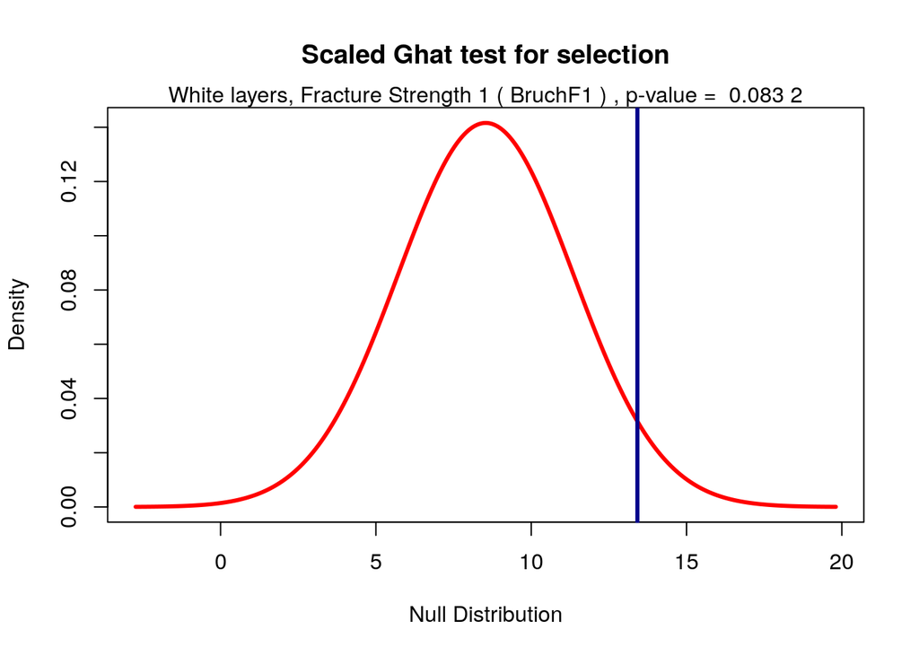

```
## [1] "Doing Permutation Test"
```

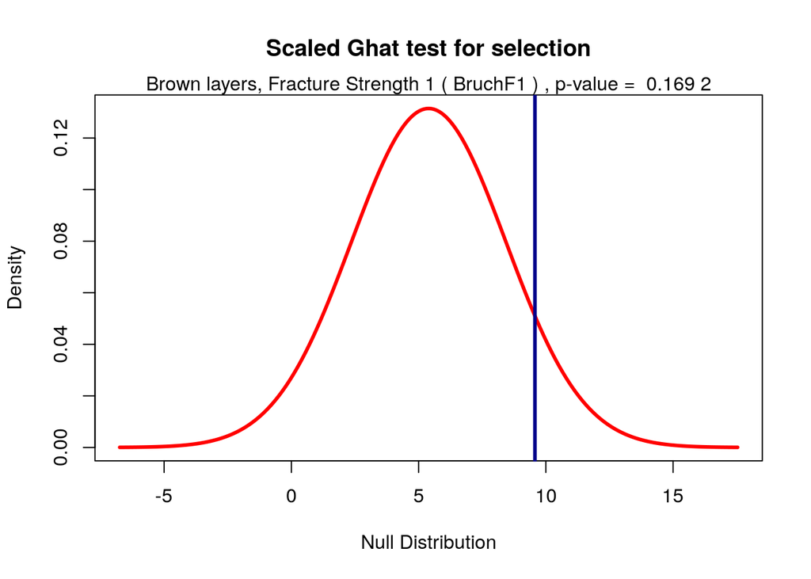

```
## [1] "Doing Permutation Test"
```

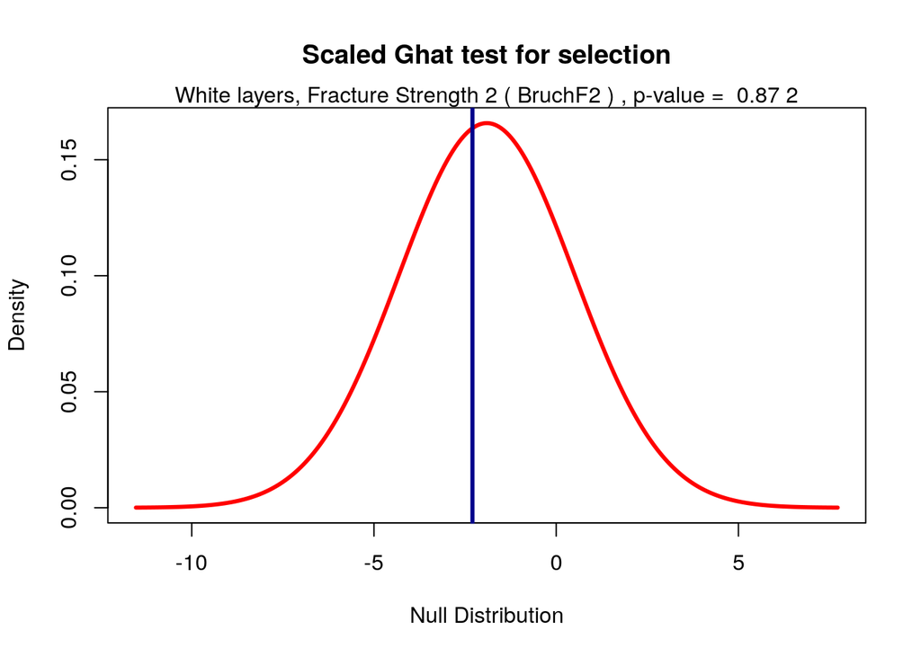

```
## [1] "Doing Permutation Test"
```

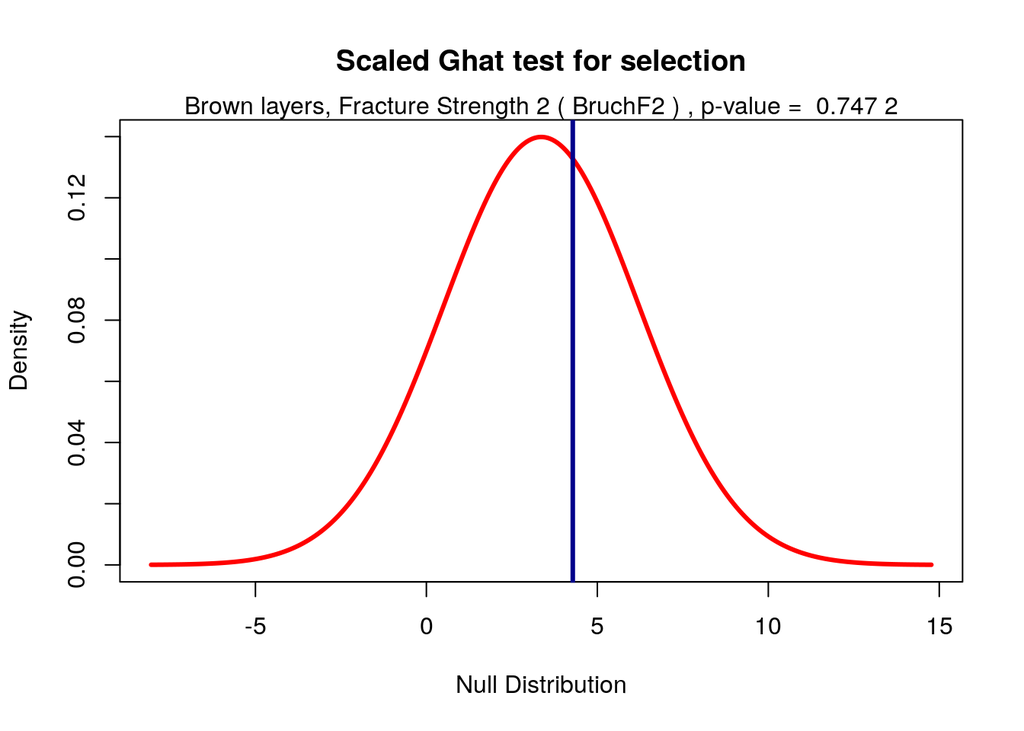

```
## [1] "Doing Permutation Test"
```

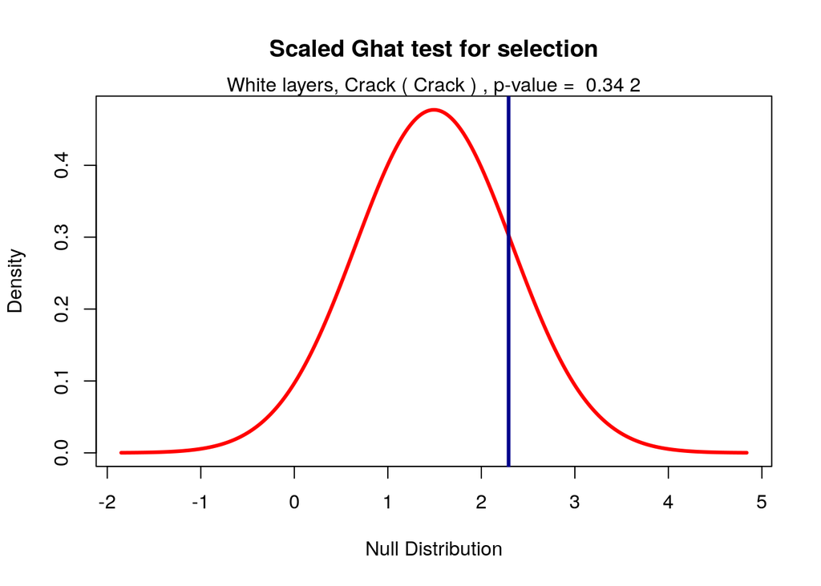

```
## [1] "Doing Permutation Test"
```

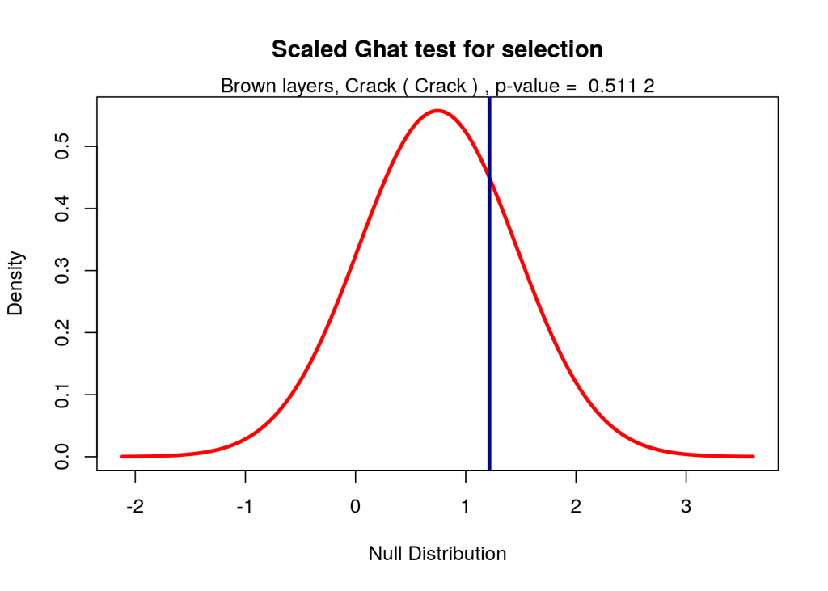

```
## [1] "Doing Permutation Test"
```

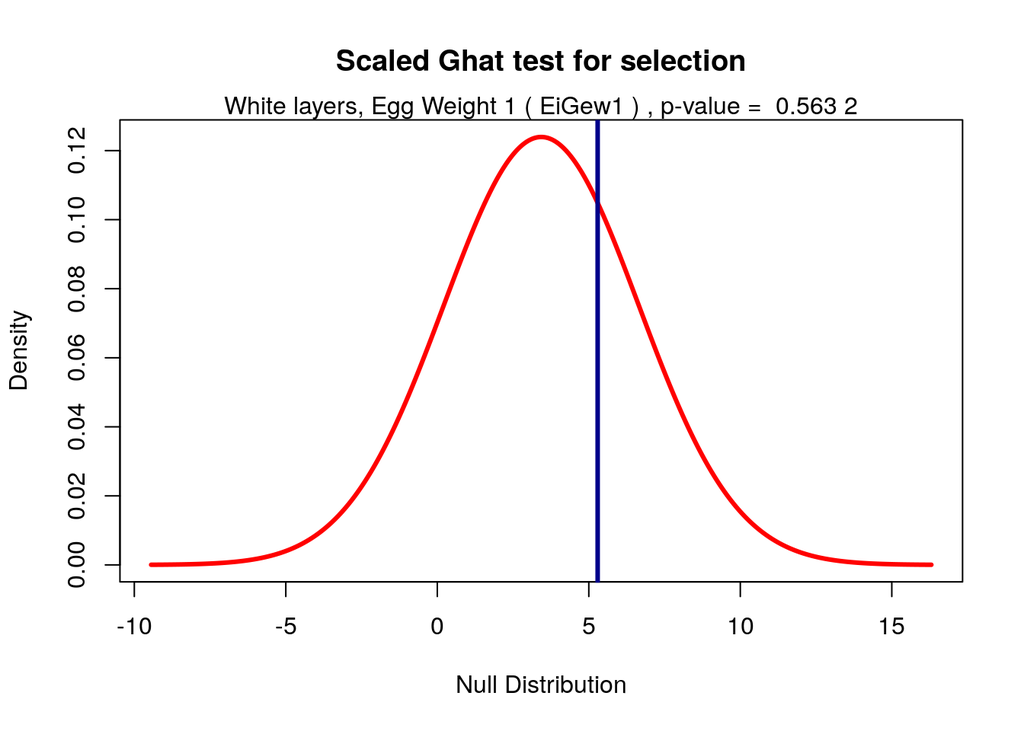

```
## [1] "Doing Permutation Test"
```

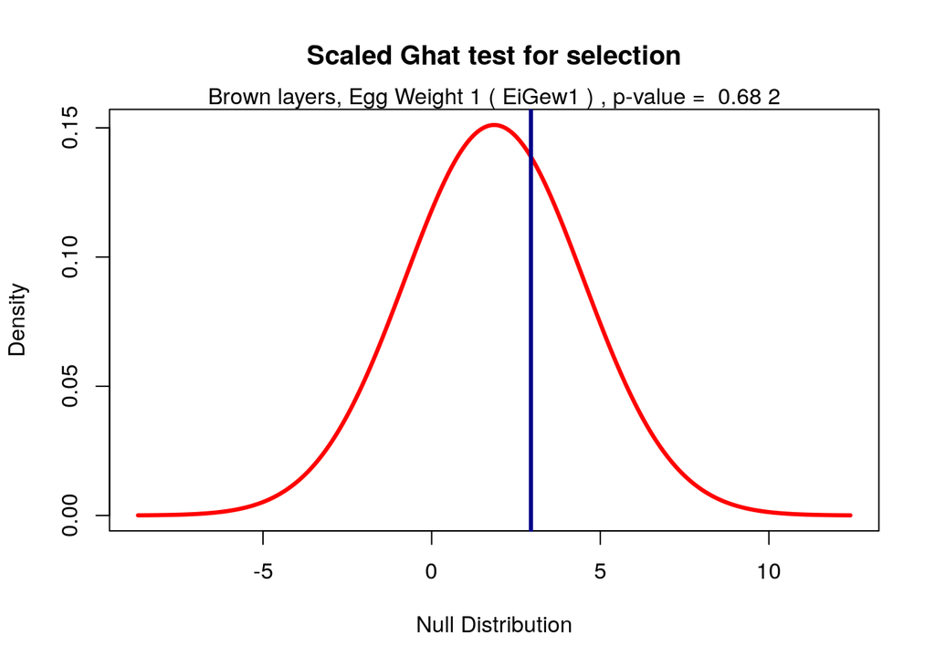

```
## [1] "Doing Permutation Test"
```

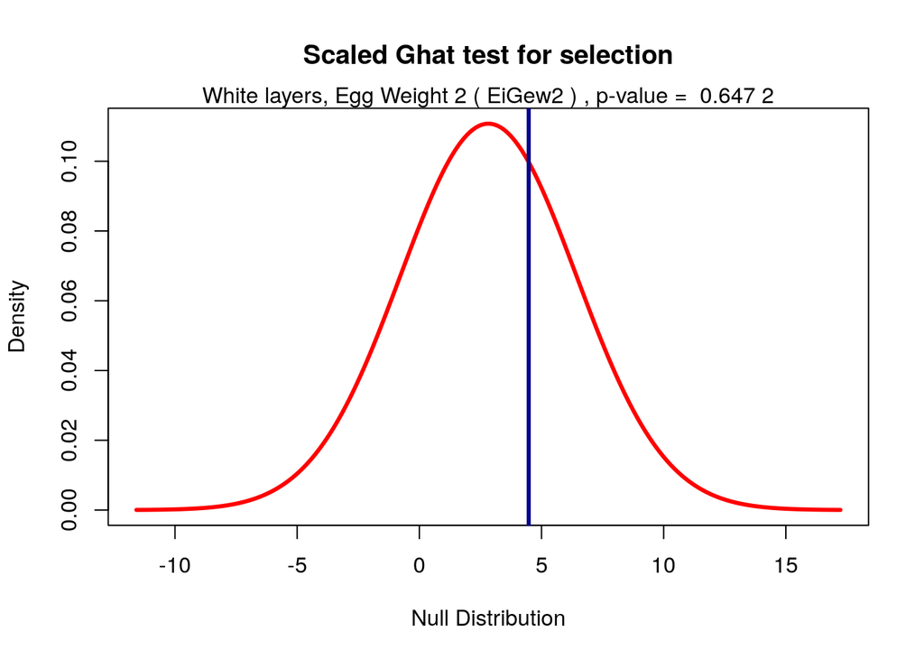

```
## [1] "Doing Permutation Test"
```

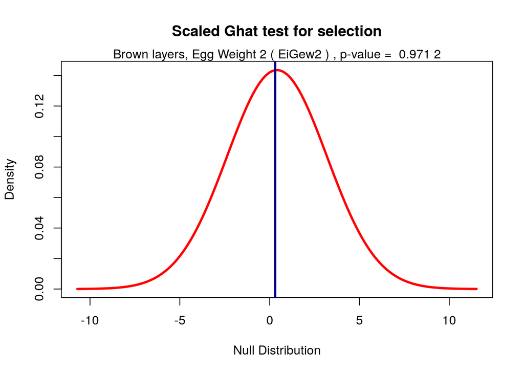

```
## [1] "Doing Permutation Test"
```

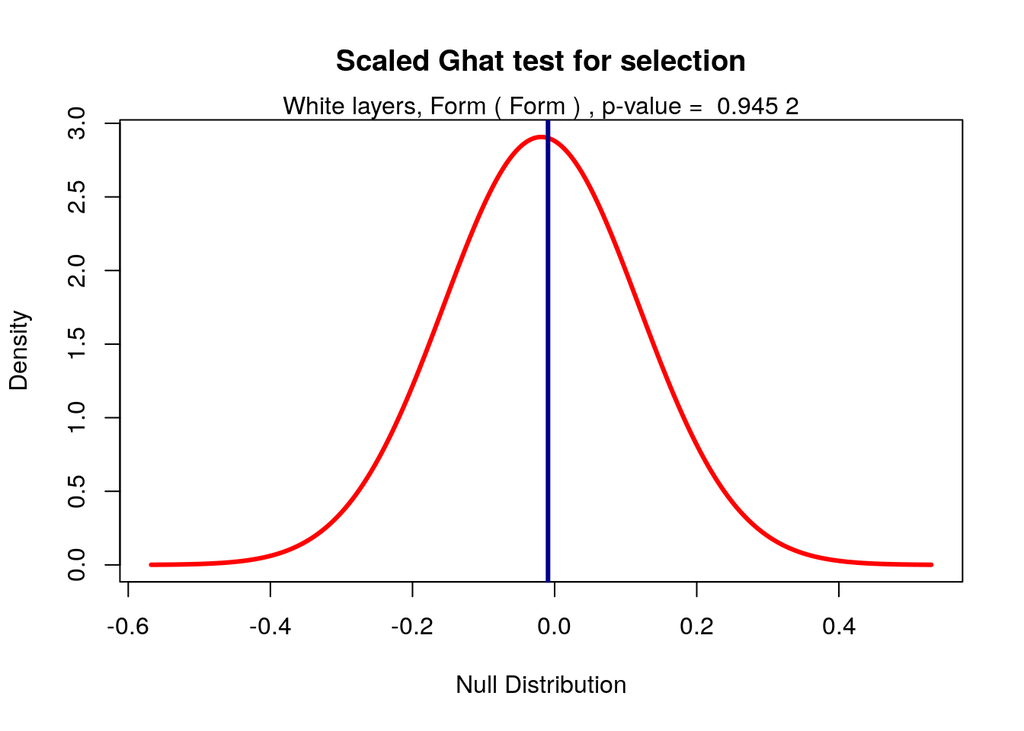

```
## [1] "Doing Permutation Test"
```

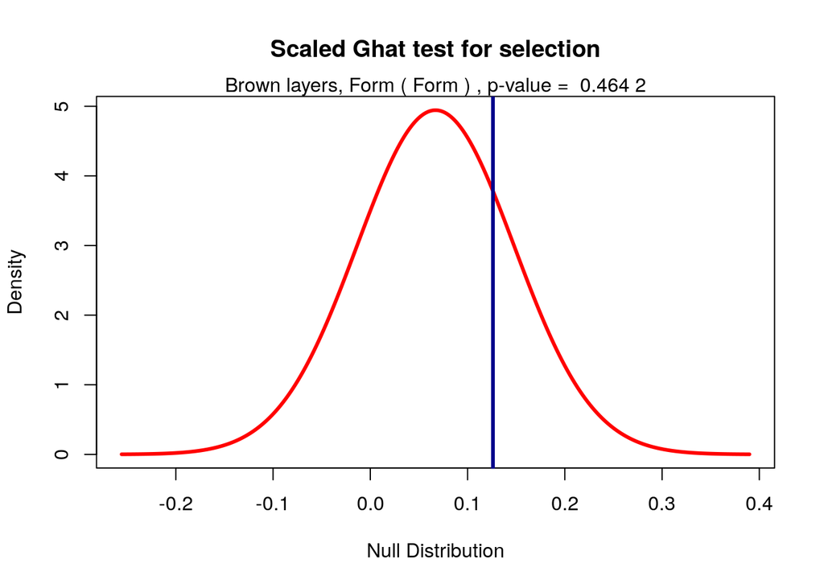

```
## [1] "Doing Permutation Test"
```

[12 more figures not shown]

```r
#white.result<-matrix(NA,nrow=2,ncol=length(white))
white.result <- list()
brown.result <- list()

traits=c("Fracture Strength 1","Fracture Strength 2","Crack","Egg Weight 1","Egg Weight 2","Form","Feed","Body Weight","Egg White","Laying Rate 1","Laying Rate 2","Laying Rate 3")
source("/home/beissinger/Documents/ComplexSelection/R-Function/Ghat.R")

for(i in 1:length(white)){
  white.result[[i]]<-Ghat_func_effectsKnown(effects=white[[i]]$alpha,change=white[[i]]$deltaP,method="scale",perms=1000,plot="Ghat",num_eff=whiteNum)
  mtext(paste("White layers,", traits[i],"(",names(white)[i] ,")", ", p-value = ", round(white.result[[i]]$p.val,3),cex=2))
  brown.result[[i]]<-Ghat_func_effectsKnown(effects=brown[[i]]$alpha,change=brown[[i]]$deltaP,method="scale",perms=1000,plot="Ghat",num_eff=brownNum)
    mtext(paste("Brown layers,", traits[i], "(",names(brown)[i],")", ", p-value = ", round(brown.result[[i]]$p.val,3),cex=2))
}
```

```r
names(white.result)<-names(white)
names(brown.result)<-names(brown)
```

Below I will make plots for the manuscript

```r
jpeg(file = "chickens_manuscript_plot_outliers_removed_EW1.jpg", height = 8, width = 6, ,units="in",res=300)
par(cex=0.6,mar=c(5,4,2,2)+0.1)
## some pretty colors
colfunc <- colorRampPalette(c("lightblue", "darkred","red","yellow"))
library(MASS)

# White laying rate
par(fig=c(0,0.5,.66666,1))
i<- 11
flip <- sample(c(-1,1),nrow(white[[i]]),replace=T) ## Flip half of frequency changes for pretty plot
whiteDeltaP <- white[[i]]$deltaP*flip
white[[i]]$deltaP <- whiteDeltaP ## End flipping of frequency changes
white[[i]]$alpha <- white[[i]]$alpha*flip ## Flip corresponding estimated effects
z <- kde2d(white[[i]]$deltaP, white[[i]]$alpha, n=200)
plot(white[[i]]$deltaP,white[[i]]$alpha,xaxt="s",yaxt="s",xlab="Frequency change",ylab="Effect size",cex.axis=0.75,main="WL laying rate")
contour(z,drawlabels=F,nlevels=500,col=colfunc(500),add=T)
abline(lm(white[[i]]$alpha~white[[i]]$deltaP),col="darkred",lwd=3)

  # Brown laying rate
par(fig=c(0.5,1,.66666,1),new=T)
i<- 11
flip <- sample(c(-1,1),nrow(brown[[i]]),replace=T) ## Flip half of frequency changes for pretty plot
brownDeltaP <- brown[[i]]$deltaP*flip
brown[[i]]$deltaP <- brownDeltaP ## End flipping of frequency changes
brown[[i]]$alpha <- brown[[i]]$alpha*flip ## Flip corresponding estimated effects
z <- kde2d(brown[[i]]$deltaP, brown[[i]]$alpha, n=200)
plot(brown[[i]]$deltaP,brown[[i]]$alpha,xaxt="s",yaxt="s",xlab="Frequency change",ylab="Effect size",cex.axis=0.75,main="BL laying rate")
contour(z,drawlabels=F,nlevels=500,col=colfunc(500),add=T)
abline(lm(brown[[i]]$alpha~brown[[i]]$deltaP),col="darkred",lwd=3)

# WHite egg weight 1
i<-4
par(fig=c(0,0.5,.33333,.66666),new=T)
flip <- sample(c(-1,1),nrow(white[[i]]),replace=T) ## Flip half of frequency changes for pretty plot
whiteDeltaP <- white[[i]]$deltaP*flip
white[[i]]$deltaP <- whiteDeltaP ## End flipping of frequency changes
white[[i]]$alpha <- white[[i]]$alpha*flip ## Flip corresponding estimated effects
z <- kde2d(white[[i]]$deltaP, white[[i]]$alpha, n=200)
plot(white[[i]]$deltaP,white[[i]]$alpha,xaxt="s",yaxt="s",xlab="Frequency change",ylab="Effect size",cex.axis=0.75,main="WL egg weight")
contour(z,drawlabels=F,nlevels=500,col=colfunc(500),add=T)
abline(lm(white[[i]]$alpha~white[[i]]$deltaP),col="darkred",lwd=3)

# Brown egg weight
i<-4
par(fig=c(0.5,1,.33333,.66666),new=T)
flip <- sample(c(-1,1),nrow(brown[[i]]),replace=T) ## Flip half of frequency changes for pretty plot
brownDeltaP <- brown[[i]]$deltaP*flip
brown[[i]]$deltaP <- brownDeltaP ## End flipping of frequency changes
brown[[i]]$alpha <- brown[[i]]$alpha*flip ## Flip corresponding estimated effects
z <- kde2d(brown[[i]]$deltaP, brown[[i]]$alpha, n=200)
plot(brown[[i]]$deltaP,brown[[i]]$alpha,xaxt="s",yaxt="s",xlab="Frequency change",ylab="Effect size",cex.axis=0.75,main="BL egg weight")
contour(z,drawlabels=F,nlevels=500,col=colfunc(500),add=T)
abline(lm(brown[[i]]$alpha~brown[[i]]$deltaP),col="darkred",lwd=3)

# WHite fracture strength
par(fig=c(0,0.5,0,.33333),new=T)
i<- 1
flip <- sample(c(-1,1),nrow(white[[i]]),replace=T) ## Flip half of frequency changes for pretty plot
whiteDeltaP <- white[[i]]$deltaP*flip
white[[i]]$deltaP <- whiteDeltaP ## End flipping of frequency changes
white[[i]]$alpha <- white[[i]]$alpha*flip ## Flip corresponding estimated effects
z <- kde2d(white[[i]]$deltaP, white[[i]]$alpha, n=200)
plot(white[[i]]$deltaP,white[[i]]$alpha,xaxt="s",yaxt="s",xlab="Frequency change",ylab="Effect size",cex.axis=0.75,main="WL eggshell breaking strength")
contour(z,drawlabels=F,nlevels=500,col=colfunc(500),add=T)
abline(lm(white[[i]]$alpha~white[[i]]$deltaP),col="darkred",lwd=3)

# Brown fracture strength
par(fig=c(0.5,1,0,.33333),new=T)
i<- 1
flip <- sample(c(-1,1),nrow(brown[[i]]),replace=T) ## Flip half of frequency changes for pretty plot
brownDeltaP <- brown[[i]]$deltaP*flip
brown[[i]]$deltaP <- brownDeltaP ## End flipping of frequency changes
brown[[i]]$alpha <- brown[[i]]$alpha*flip ## Flip corresponding estimated effects
z <- kde2d(brown[[i]]$deltaP, brown[[i]]$alpha, n=200)
plot(brown[[i]]$deltaP,brown[[i]]$alpha,xaxt="s",yaxt="s",xlab="Frequency change",ylab="Effect size",cex.axis=0.75,main="BL eggshell breaking strength")
contour(z,drawlabels=F,nlevels=500,col=colfunc(500),add=T)
abline(lm(brown[[i]]$alpha~brown[[i]]$deltaP),col="darkred",lwd=3)


#############
###insets####
#############
par(cex=0.55)
#white laying rate
i<-11
par(fig=c(.83-.275-.5,.99-.275-.5,.84,.965),mgp=c(1,.3,0), new=TRUE)
par(mar=c(2,2,0,0))
left <- min(mean(white.result[[i]]$Ghat_perm)-4*white.result[[i]]$sd_eff,white.result[[i]]$Ghat)
right <- max(mean(white.result[[i]]$Ghat_perm)+4*white.result[[i]]$sd_eff,white.result[[i]]$Ghat)
plot(seq(left,right,length.out=1000),dnorm(seq(left,right,length.out=1000),mean=mean(white.result[[i]]$Ghat_perm),sd=white.result[[i]]$sd_eff),col="red",lwd=2,type="l",yaxt="n",ylab="",xlab="",xaxt="n",main="")
rect(par("usr")[1], par("usr")[3], par("usr")[2], par("usr")[4], col = "gray")
lines(seq(left,right,length.out=1000),dnorm(seq(left,right,length.out=1000),mean=mean(white.result[[i]]$Ghat_perm),sd=white.result[[i]]$sd_eff),col="red",lwd=2)
abline(v=white.result[[i]]$Ghat,lwd=2,col="darkblue")
text(par("usr")[1]+.18*(par("usr")[2]-par("usr")[1]),par("usr")[3]+0.8*(par("usr")[4]-par("usr")[3]),paste("p =  \n", sprintf("%.3f",round(white.result[[i]]$p.val,3))),cex=1.1,font=2)


#brown laying rate
i<-11
par(fig=c(.83-.275,.99-.275,.84,.965),mgp=c(1,.3,0), new=TRUE)
par(mar=c(2,2,0,0))
left <- min(mean(brown.result[[i]]$Ghat_perm)-4*brown.result[[i]]$sd_eff,brown.result[[i]]$Ghat)
right <- max(mean(brown.result[[i]]$Ghat_perm)+4*brown.result[[i]]$sd_eff,brown.result[[i]]$Ghat)
plot(seq(left,right,length.out=1000),dnorm(seq(left,right,length.out=1000),mean=mean(brown.result[[i]]$Ghat_perm),sd=brown.result[[i]]$sd_eff),col="red",lwd=2,type="l",yaxt="n",ylab="",xlab="",xaxt="n",main="")
rect(par("usr")[1], par("usr")[3], par("usr")[2], par("usr")[4], col = "gray")
lines(seq(left,right,length.out=1000),dnorm(seq(left,right,length.out=1000),mean=mean(brown.result[[i]]$Ghat_perm),sd=brown.result[[i]]$sd_eff),col="red",lwd=2)
abline(v=brown.result[[i]]$Ghat,lwd=2,col="darkblue")
text(par("usr")[1]+.18*(par("usr")[2]-par("usr")[1]),par("usr")[3]+0.8*(par("usr")[4]-par("usr")[3]),paste("p =  \n", sprintf("%.3f",round(brown.result[[i]]$p.val,3))),cex=1.1,font=2)

#white egg weight 1
par(fig=c(.83-.275-.5,.99-.275-.5,.84-.33333,.965-.33333),mgp=c(1,.3,0), new=TRUE)
par(mar=c(2,2,0,0))
i<- 4
left <- min(mean(white.result[[i]]$Ghat_perm)-4*white.result[[i]]$sd_eff,white.result[[i]]$Ghat)
right <- max(mean(white.result[[i]]$Ghat_perm)+4*white.result[[i]]$sd_eff,white.result[[i]]$Ghat)
plot(seq(left,right,length.out=1000),dnorm(seq(left,right,length.out=1000),mean=mean(white.result[[i]]$Ghat_perm),sd=white.result[[i]]$sd_eff),col="red",lwd=2,type="l",yaxt="n",ylab="",xlab="",xaxt="n",main="")
rect(par("usr")[1], par("usr")[3], par("usr")[2], par("usr")[4], col = "gray")
lines(seq(left,right,length.out=1000),dnorm(seq(left,right,length.out=1000),mean=mean(white.result[[i]]$Ghat_perm),sd=white.result[[i]]$sd_eff),col="red",lwd=2)
abline(v=white.result[[i]]$Ghat,lwd=2,col="darkblue")
text(par("usr")[1]+.18*(par("usr")[2]-par("usr")[1]),par("usr")[3]+0.8*(par("usr")[4]-par("usr")[3]),paste("p =  \n", sprintf("%.3f",round(white.result[[i]]$p.val,3))),cex=1.1,font=2)



#brown egg weight 1
par(fig=c(.83-.275,.99-.275,.84-.33333,.965-.33333),mgp=c(1,.3,0), new=TRUE)
par(mar=c(2,2,0,0))
i<- 4
left <- min(mean(brown.result[[i]]$Ghat_perm)-4*brown.result[[i]]$sd_eff,brown.result[[i]]$Ghat)
right <- max(mean(brown.result[[i]]$Ghat_perm)+4*brown.result[[i]]$sd_eff,brown.result[[i]]$Ghat)
plot(seq(left,right,length.out=1000),dnorm(seq(left,right,length.out=1000),mean=mean(brown.result[[i]]$Ghat_perm),sd=brown.result[[i]]$sd_eff),col="red",lwd=2,type="l",yaxt="n",ylab="",xlab="",xaxt="n",main="")
rect(par("usr")[1], par("usr")[3], par("usr")[2], par("usr")[4], col = "gray")
lines(seq(left,right,length.out=1000),dnorm(seq(left,right,length.out=1000),mean=mean(brown.result[[i]]$Ghat_perm),sd=brown.result[[i]]$sd_eff),col="red",lwd=2)
abline(v=brown.result[[i]]$Ghat,lwd=2,col="darkblue")
text(par("usr")[1]+.18*(par("usr")[2]-par("usr")[1]),par("usr")[3]+0.8*(par("usr")[4]-par("usr")[3]),paste("p =  \n", sprintf("%.3f",round(brown.result[[i]]$p.val,3))),cex=1.1,font=2)


#white fracture strength
i<-1
par(fig=c(.83-.275-.5,.99-.275-.5,.84-.666666,.965-.666666),mgp=c(1,.3,0), new=TRUE)
par(mar=c(2,2,0,0))
left <- min(mean(white.result[[i]]$Ghat_perm)-4*white.result[[i]]$sd_eff,white.result[[i]]$Ghat)
right <- max(mean(white.result[[i]]$Ghat_perm)+4*white.result[[i]]$sd_eff,white.result[[i]]$Ghat)
plot(seq(left,right,length.out=1000),dnorm(seq(left,right,length.out=1000),mean=mean(white.result[[i]]$Ghat_perm),sd=white.result[[i]]$sd_eff),col="red",lwd=2,type="l",yaxt="n",ylab="",xlab="",xaxt="n",main="")
rect(par("usr")[1], par("usr")[3], par("usr")[2], par("usr")[4], col = "gray")
lines(seq(left,right,length.out=1000),dnorm(seq(left,right,length.out=1000),mean=mean(white.result[[i]]$Ghat_perm),sd=white.result[[i]]$sd_eff),col="red",lwd=2)
abline(v=white.result[[i]]$Ghat,lwd=2,col="darkblue")
text(par("usr")[1]+.18*(par("usr")[2]-par("usr")[1]),par("usr")[3]+0.8*(par("usr")[4]-par("usr")[3]),paste("p =  \n", sprintf("%.3f",round(white.result[[i]]$p.val,3))),cex=1.1,font=2)



#brown fracture strength
i<-1
par(fig=c(.83-.275,.99-.275,.84-.666666,.965-.666666),mgp=c(1,.3,0), new=TRUE)
par(mar=c(2,2,0,0))
left <- min(mean(brown.result[[i]]$Ghat_perm)-4*brown.result[[i]]$sd_eff,brown.result[[i]]$Ghat)
right <- max(mean(brown.result[[i]]$Ghat_perm)+4*brown.result[[i]]$sd_eff,brown.result[[i]]$Ghat)
plot(seq(left,right,length.out=1000),dnorm(seq(left,right,length.out=1000),mean=mean(brown.result[[i]]$Ghat_perm),sd=brown.result[[i]]$sd_eff),col="red",lwd=2,type="l",yaxt="n",ylab="",xlab="",xaxt="n",main="")
rect(par("usr")[1], par("usr")[3], par("usr")[2], par("usr")[4], col = "gray")
lines(seq(left,right,length.out=1000),dnorm(seq(left,right,length.out=1000),mean=mean(brown.result[[i]]$Ghat_perm),sd=brown.result[[i]]$sd_eff),col="red",lwd=2)
abline(v=brown.result[[i]]$Ghat,lwd=2,col="darkblue")
text(par("usr")[1]+.18*(par("usr")[2]-par("usr")[1]),par("usr")[3]+0.8*(par("usr")[4]-par("usr")[3]),paste("p =  \n", sprintf("%.3f",round(brown.result[[i]]$p.val,3))),cex=1.1,font=2)


dev.off()
```

Plots below show cumulative sum. Don’t bother for now (Ignore = T).

```r
### Calculations and Pretty plots below (white)

#cum.w.ew <-c(white[[5]]$alpha[1]*white[[5]]$deltaP[1])
#for(i in 2:nrow(white[[5]])){
#  print(i)
#  cum.w.ew[i] <- cum.w.ew[i-1]+white[[5]]$alpha[i]*white[[5]]$deltaP[i]
#}

is.odd <- function(x) x %% 2 != 0

chrColors <- white[[5]]$chr
chrColors[which(is.odd(chrColors))] <- "#848B9B"
chrColors[which(is.odd(as.numeric(chrColors))==F)] <- "#25282E" #Warning OK

plotrows<-white[[1]][,c(5,6,7)]
plotrows<-cbind(plotrows,1:nrow(plotrows))
names(plotrows)[4]<-"index"

png("cumulative_white.png",height=7,width=17,units="in",res=200,pointsize=18)
plot(cum.w.ew,col=chrColors,xaxt="n",xlab="chromosome",ylab="Cum. sum",cex.legend=2,cex.main=2,main="Egg Weight")
abline(h=quantile(permuted[1,5,],c(0.025,0.975)),col="darkblue")
legend("topleft","c(x,y)","Significance thresholds",col="darkblue",pch="=", bg="white",cex=1.7)
axis(1,1:28,at=aggregate( plotrows$index,by=list(plotrows$chr),FUN=median)$x)
dev.off()

### Calculations and pretty plots below (brown)
#cum.b.ew <- c(brown[[5]]$alpha[1]*brown[[5]]$deltaP[1])
#for(i in 2:nrow(brown[[5]])){
#  print(i)
#  cum.b.ew[i] <- cum.b.ew[i-1]+brown[[5]]$alpha[i]*brown[[5]]$deltaP[i]
#}


is.odd <- function(x) x %% 2 != 0

chrColors <- brown[[5]]$chr
chrColors[which(is.odd(chrColors))] <- "#848B9B"
chrColors[which(is.odd(as.numeric(chrColors))==F)] <- "#25282E" #Warning OK

plotrows<-brown[[5]][,c(5,6,7)]
plotrows<-cbind(plotrows,1:nrow(plotrows))
names(plotrows)[4]<-"index"


png("cumulative_brown.png",height=7,width=17,units="in",res=200,pointsize=18)
plot(cum.b.ew,col=chrColors,xaxt="n",xlab="chromosome",ylab="Cum. sum",cex.legend=2,cex.main=2,main="Egg Weight")
abline(h=quantile(permuted[2,5,],c(0.025,0.975)),col="darkblue")
legend("topright","c(x,y)","Significance thresholds",col="darkblue",pch="=", bg="white",cex=1.7)
axis(1,1:28,at=aggregate( plotrows$index,by=list(plotrows$chr),FUN=median)$x)
dev.off()
```